### Chapter 7 Tutorial: Decision Trees

Granger Moch and Sam Eckhardt

# Load Data

```r
> data(CCS, package="BCA")
```

# Create 50/50 Sample

```r
> CCS$Sample <- create.samples(CCS, est = 0.50, val = 0.50, rand.seed = 1)
```

We created estimation and validation samples, much like we did in the logistic regression tutorial. The validation sample will later be used to evaluate the estimation model.

# Create tree1CCS model

```r
> tree1CCS <- rpart(MonthGive ~ AdultAge + Age20t29 + Age20t39 + Age60pls +
+   Age80pls + Age70pls + AveDonAmt + AveIncEA + DonPerYear + DwelValEA +
+   EngPrmLang + FinUnivP + hh1mem + hh1t2mem + LastDonAmt + NewDonor + Region +
+   SomeUnivP + YearsGive, data=CCS, cp=0.01, subset=Sample == "Estimation")
> tree1CCS # Tree Leaf Summary
```

```
n= 800

node), split, n, loss, yval, (yprob)
      * denotes terminal node

  1) root 800 397 No (0.5037500 0.4962500)
    2) AveDonAmt< 11.83333 243  42 No (0.8271605 0.1728395)
      4) DonPerYear>=0.09545455 236  36 No (0.8474576 0.1525424) *
      5) DonPerYear< 0.09545455 7   1 Yes (0.1428571 0.8571429) *
    3) AveDonAmt>=11.83333 557 202 Yes (0.3626571 0.6373429)
      6) AveDonAmt< 23.54167 192  96 No (0.5000000 0.5000000)
       12) AveIncEA>=54606.5 88  30 No (0.6590909 0.3409091) *
       13) AveIncEA< 54606.5 104  38 Yes (0.3653846 0.6346154)
         26) DonPerYear< 1.125 91  38 Yes (0.4175824 0.5824176)
           52) SomeUnivP>=0.2053262 54  24 No (0.5555556 0.4444444)
            104) SomeUnivP< 0.313709 39  13 No (0.6666667 0.3333333) *
            105) SomeUnivP>=0.313709 15   4 Yes (0.2666667 0.7333333) *
           53) SomeUnivP< 0.2053262 37   8 Yes (0.2162162 0.7837838) *
         27) DonPerYear>=1.125 13   0 Yes (0.0000000 1.0000000) *
      7) AveDonAmt>=23.54167 365 106 Yes (0.2904110 0.7095890) *
```

This model uses all of the original variables from the CCS dataset with MonthGive as the target variable.

# Plot of tree1CCS model without uniform branch distance

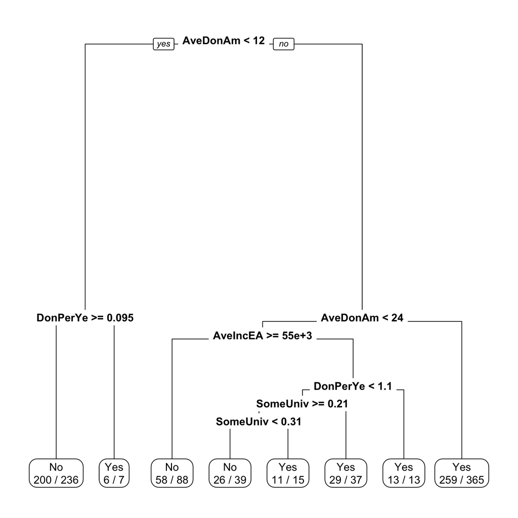

```r
> rpart.plot(tree1CCS, type = 0, extra = 2, uniform = FALSE, fallen.leaves =
+   TRUE)
```

This plot shows the best first split is on AveDonAmt at $12. Having branch length indicate the relative strength of relationships can be useful, but it can also make it difficult to read and interpret the plot.

# Plot of tree1CCS model with uniform branch distance

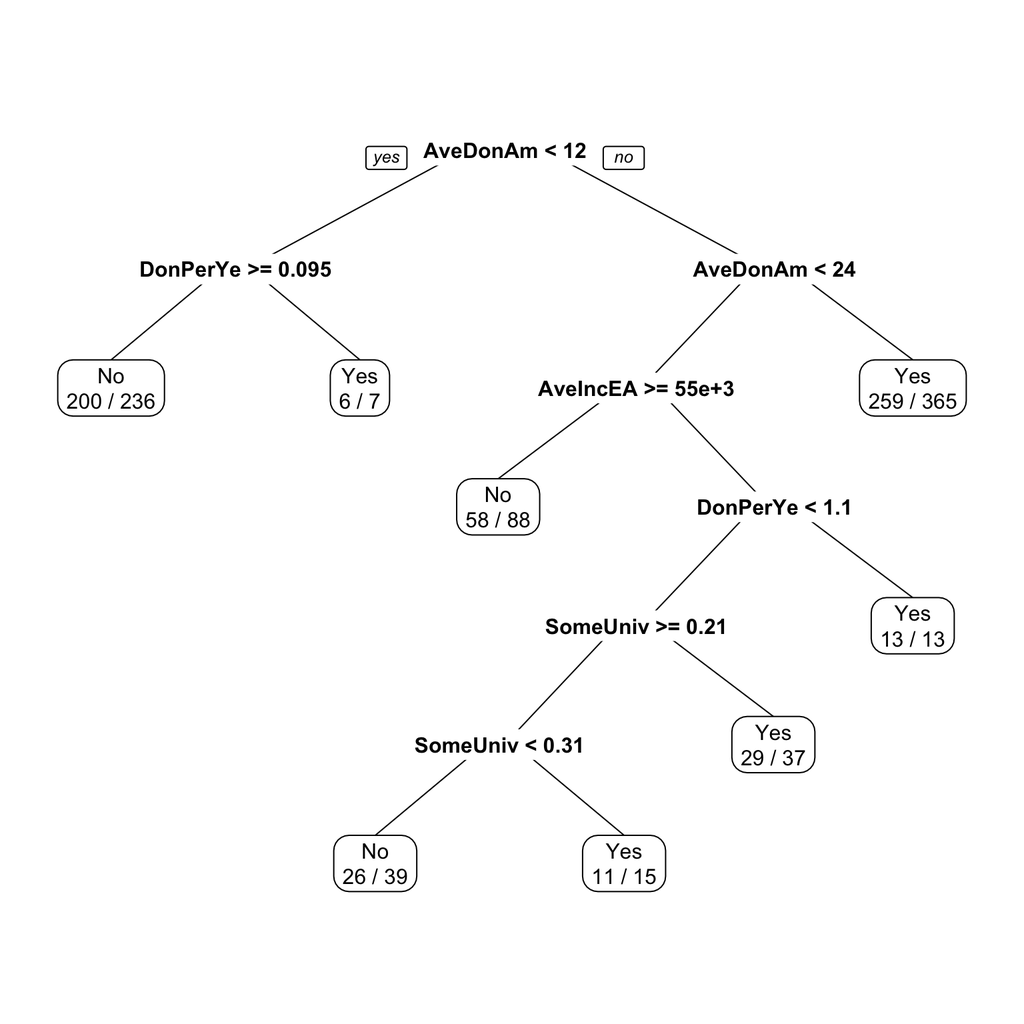

```r
> rpart.plot(tree1CCS, type = 0, extra = 2, uniform = TRUE, fallen.leaves =
+   FALSE)
```

The uniform branch length makes reading labels a bit easier.

# Model showing proportions

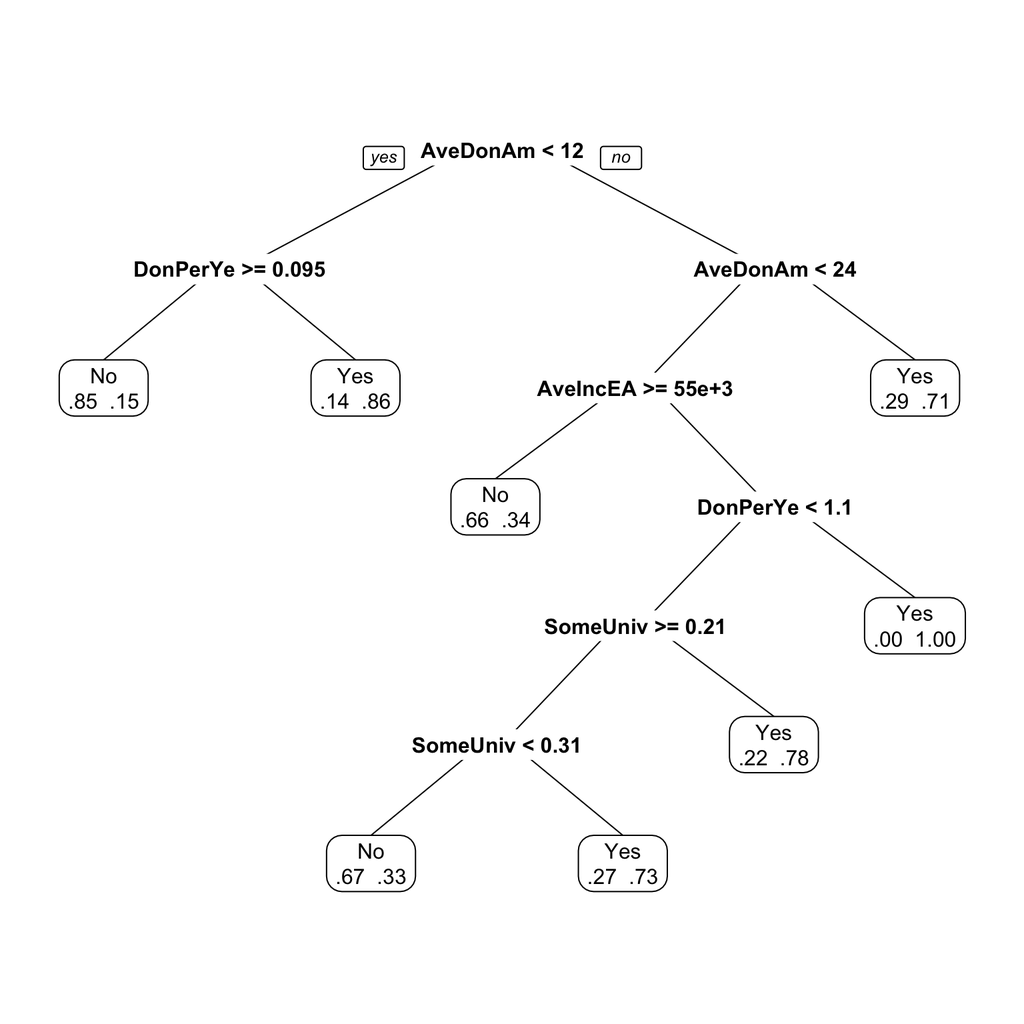

```r
> rpart.plot(tree1CCS, type = 0, extra = 4, uniform = TRUE, fallen.leaves =
+   FALSE)
```

This plot shows the proportions of the two values of the target variable at each leaf.

# Create Log Variable

```r
> CCS$Log.AveDonAmt <- with(CCS, log(AveDonAmt))
```

The use of this variable in the following models is to demonstrate that log transformations are not as beneficial for decision trees as they can be with logistic regression.

# New model using log variable

```r
> tree2CCS <- rpart(MonthGive ~ AdultAge + Age20t29 + Age20t39 + Age60pls +
+   Age80pls + Age70pls  + AveIncEA + DonPerYear + DwelValEA + EngPrmLang +
+   FinUnivP + hh1mem + hh1t2mem + LastDonAmt + NewDonor + Region + SomeUnivP +
+   YearsGive + Log.AveDonAmt, data=CCS, cp=0.01, subset=Sample == "Estimation")
> tree2CCS # Tree Leaf Summary
```

```
n= 800

node), split, n, loss, yval, (yprob)
      * denotes terminal node

  1) root 800 397 No (0.5037500 0.4962500)
    2) Log.AveDonAmt< 2.470821 243  42 No (0.8271605 0.1728395)
      4) DonPerYear>=0.09545455 236  36 No (0.8474576 0.1525424) *
      5) DonPerYear< 0.09545455 7   1 Yes (0.1428571 0.8571429) *
    3) Log.AveDonAmt>=2.470821 557 202 Yes (0.3626571 0.6373429)
      6) Log.AveDonAmt< 3.158733 192  96 No (0.5000000 0.5000000)
       12) AveIncEA>=54606.5 88  30 No (0.6590909 0.3409091) *
       13) AveIncEA< 54606.5 104  38 Yes (0.3653846 0.6346154)
         26) DonPerYear< 1.125 91  38 Yes (0.4175824 0.5824176)
           52) SomeUnivP>=0.2053262 54  24 No (0.5555556 0.4444444)
            104) SomeUnivP< 0.313709 39  13 No (0.6666667 0.3333333) *
            105) SomeUnivP>=0.313709 15   4 Yes (0.2666667 0.7333333) *
           53) SomeUnivP< 0.2053262 37   8 Yes (0.2162162 0.7837838) *
         27) DonPerYear>=1.125 13   0 Yes (0.0000000 1.0000000) *
      7) Log.AveDonAmt>=3.158733 365 106 Yes (0.2904110 0.7095890) *
```

# Plot of new model

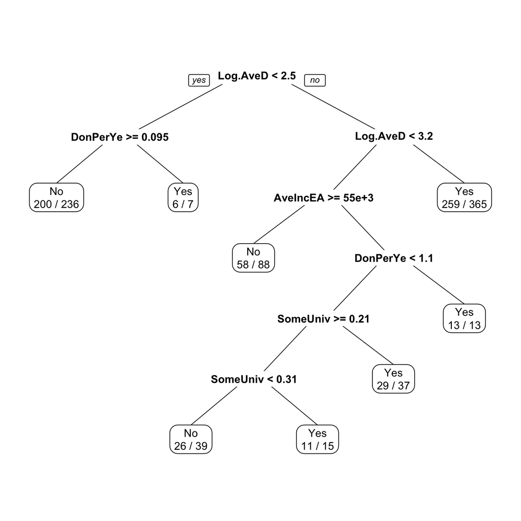

```r
> rpart.plot(tree2CCS, type = 0, extra = 2, uniform = TRUE, fallen.leaves =
+   FALSE)
```

# Delete Log Variable

```r
> CCS <- within(CCS, {
+   Log.AveDonAmt <- NULL
+ })
```

This variable is deleted because ultimately it produced a tree with the same members in the same groups as the non log-transformed model.

# Rerun model as “TreeNoADA”, without AveDonAmt

```r
> TreeNoADA <- rpart(MonthGive ~ AdultAge + Age20t29 + Age20t39 + Age60pls +
+   Age80pls + Age70pls + AveIncEA + DonPerYear + DwelValEA + EngPrmLang +
+   FinUnivP + hh1mem + hh1t2mem + LastDonAmt + NewDonor + Region + SomeUnivP +
+   YearsGive, data=CCS, cp=0.01, subset=Sample == "Estimation")
> TreeNoADA # Tree Leaf Summary
```

```
n= 800

node), split, n, loss, yval, (yprob)
      * denotes terminal node

  1) root 800 397 No (0.50375000 0.49625000)
    2) LastDonAmt< 11.5 285  65 No (0.77192982 0.22807018) *
    3) LastDonAmt>=11.5 515 183 Yes (0.35533981 0.64466019)
      6) LastDonAmt< 22.5 149  73 No (0.51006711 0.48993289)
       12) Region=R1,R2,R4,R5,R6 128  55 No (0.57031250 0.42968750)
         24) AveIncEA>=54606.5 63  17 No (0.73015873 0.26984127) *
         25) AveIncEA< 54606.5 65  27 Yes (0.41538462 0.58461538)
           50) SomeUnivP>=0.1906273 48  23 No (0.52083333 0.47916667)
            100) SomeUnivP< 0.3285714 36  12 No (0.66666667 0.33333333) *
            101) SomeUnivP>=0.3285714 12   1 Yes (0.08333333 0.91666667) *
           51) SomeUnivP< 0.1906273 17   2 Yes (0.11764706 0.88235294) *
       13) Region=R3 21   3 Yes (0.14285714 0.85714286) *
      7) LastDonAmt>=22.5 366 107 Yes (0.29234973 0.70765027) *
```

This model excludes AveDonAmt and as a result, LastDonAmt can now have a significant effect on the target variable. This is indicative that the two variables are correlated.

# Plot of TreeNoADA

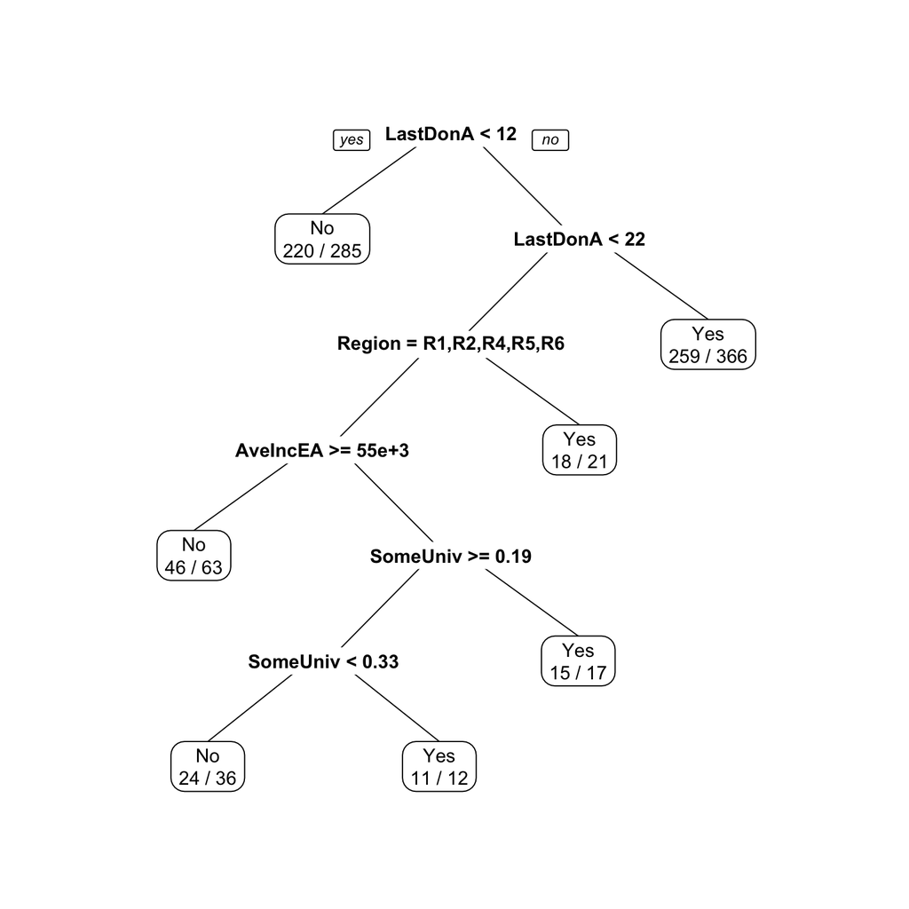

```r
> rpart.plot(TreeNoADA, type = 0, extra = 2, uniform = TRUE, fallen.leaves =
+   FALSE)
```

# Investigate potential correlation between variables in noAorLDA model

AveDonAmt and LastDonAmt were removed from this model

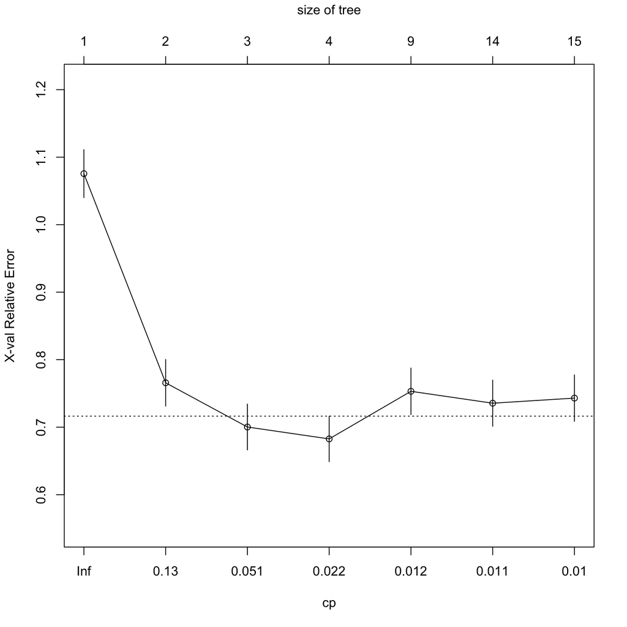

```r
> noAorLDA <- rpart(MonthGive ~ AdultAge + Age20t29 + Age20t39 + Age60pls +
+   Age80pls + Age70pls + AveIncEA + DonPerYear + DwelValEA + EngPrmLang + FinUnivP
+   + hh1mem + hh1t2mem +  NewDonor + Region + SomeUnivP + YearsGive, data=CCS,
+   cp=0.01, subset=Sample == "Estimation")
> plotcp(noAorLDA)
```

```r
> printcp(noAorLDA) # Pruning Table
```

```
Classification tree:
rpart(formula = MonthGive ~ AdultAge + Age20t29 + Age20t39 +
    Age60pls + Age80pls + Age70pls + AveIncEA + DonPerYear +
    DwelValEA + EngPrmLang + FinUnivP + hh1mem + hh1t2mem + NewDonor +
    Region + SomeUnivP + YearsGive, data = CCS, subset = Sample ==
    "Estimation", cp = 0.01)

Variables actually used in tree construction:
[1] AdultAge   AveIncEA   DonPerYear EngPrmLang hh1mem     Region
[7] SomeUnivP  YearsGive

Root node error: 397/800 = 0.49625

n= 800

        CP nsplit rel error  xerror     xstd
1 0.234257      0   1.00000 1.07557 0.035541
2 0.068010      1   0.76574 0.76574 0.034581
3 0.037783      2   0.69773 0.70025 0.033925
4 0.012594      3   0.65995 0.68262 0.033719
5 0.011587      8   0.59446 0.75315 0.034468
6 0.010076     13   0.53652 0.73552 0.034299
7 0.010000     14   0.52645 0.74307 0.034373
```

```r
> noAorLDA # Tree Leaf Summary
```

```
n= 800

node), split, n, loss, yval, (yprob)
      * denotes terminal node

  1) root 800 397 No (0.5037500 0.4962500)
    2) DonPerYear< 0.5227273 489 195 No (0.6012270 0.3987730)
      4) DonPerYear>=0.08712121 462 168 No (0.6363636 0.3636364)
        8) hh1mem< 0.3619902 395 127 No (0.6784810 0.3215190)
         16) YearsGive< 3.5 110  21 No (0.8090909 0.1909091) *
         17) YearsGive>=3.5 285 106 No (0.6280702 0.3719298)
           34) DonPerYear< 0.4083333 224  73 No (0.6741071 0.3258929)
             68) Region=R1,R2,R4,R5,R6 196  56 No (0.7142857 0.2857143) *
             69) Region=R3 28  11 Yes (0.3928571 0.6071429) *
           35) DonPerYear>=0.4083333 61  28 Yes (0.4590164 0.5409836)
             70) EngPrmLang< 0.9916247 51  24 No (0.5294118 0.4705882)
              140) SomeUnivP< 0.4771062 38  13 No (0.6578947 0.3421053) *
              141) SomeUnivP>=0.4771062 13   2 Yes (0.1538462 0.8461538) *
             71) EngPrmLang>=0.9916247 10   1 Yes (0.1000000 0.9000000) *
        9) hh1mem>=0.3619902 67  26 Yes (0.3880597 0.6119403)
         18) AveIncEA< 25448 8   2 No (0.7500000 0.2500000) *
         19) AveIncEA>=25448 59  20 Yes (0.3389831 0.6610169) *
      5) DonPerYear< 0.08712121 27   0 Yes (0.0000000 1.0000000) *
    3) DonPerYear>=0.5227273 311 109 Yes (0.3504823 0.6495177)
      6) DonPerYear< 1.071429 247  98 Yes (0.3967611 0.6032389)
       12) Region=R1,R3,R5 138  66 Yes (0.4782609 0.5217391)
         24) AdultAge>=46.69826 75  30 No (0.6000000 0.4000000)
           48) YearsGive< 2.5 39  10 No (0.7435897 0.2564103) *
           49) YearsGive>=2.5 36  16 Yes (0.4444444 0.5555556)
             98) SomeUnivP>=0.2261994 15   4 No (0.7333333 0.2666667) *
             99) SomeUnivP< 0.2261994 21   5 Yes (0.2380952 0.7619048) *
         25) AdultAge< 46.69826 63  21 Yes (0.3333333 0.6666667) *
       13) Region=R2,R4,R6 109  32 Yes (0.2935780 0.7064220) *
      7) DonPerYear>=1.071429 64  11 Yes (0.1718750 0.8281250) *
```

# Model with adjusted complexity paremeter(.04)

```r
> noAorLDA04 <- rpart(MonthGive ~ AdultAge + Age20t29 + Age20t39 + Age60pls +
+   Age80pls + Age70pls + AveIncEA + DonPerYear + DwelValEA + EngPrmLang +
+   FinUnivP + hh1mem + hh1t2mem + NewDonor + Region + SomeUnivP + YearsGive,
+   data=CCS, cp=0.04, subset=Sample == "Estimation")
> noAorLDA04 # Tree Leaf Summary
```

```
n= 800

node), split, n, loss, yval, (yprob)
      * denotes terminal node

1) root 800 397 No (0.5037500 0.4962500)
  2) DonPerYear< 0.5227273 489 195 No (0.6012270 0.3987730)
    4) DonPerYear>=0.08712121 462 168 No (0.6363636 0.3636364) *
    5) DonPerYear< 0.08712121 27   0 Yes (0.0000000 1.0000000) *
  3) DonPerYear>=0.5227273 311 109 Yes (0.3504823 0.6495177) *
```

## Plot

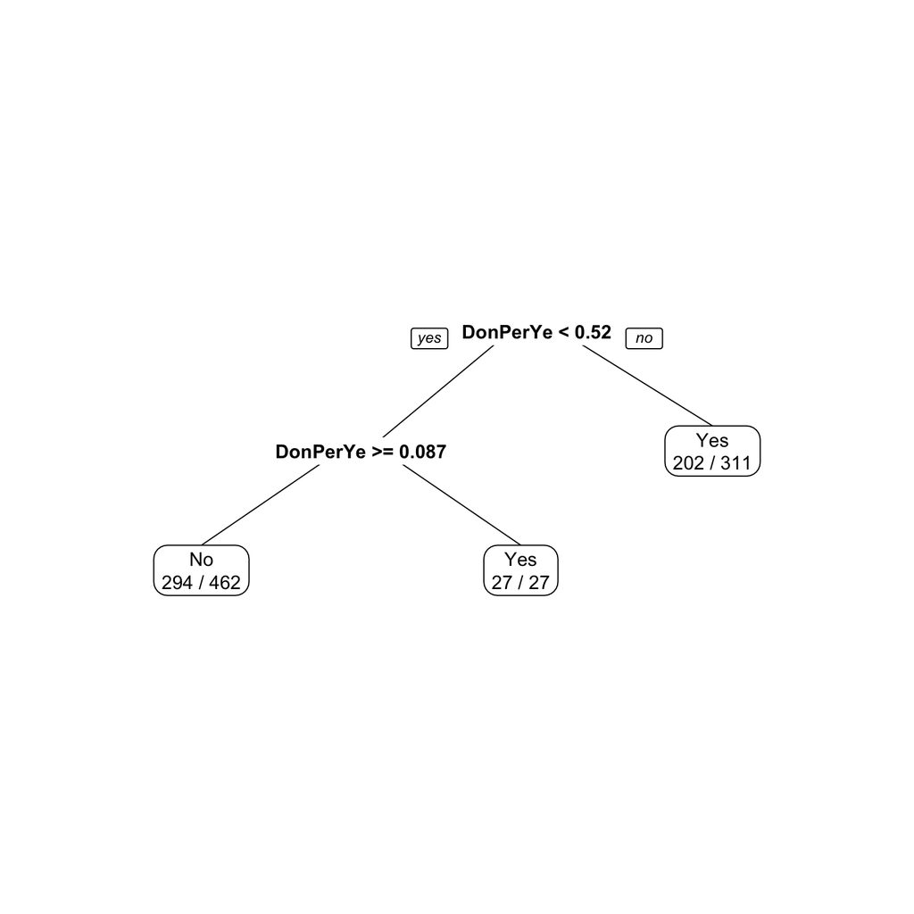

```r
> rpart.plot(noAorLDA04, type = 0, extra = 2, uniform = TRUE, fallen.leaves =
+   FALSE)
```

# Second model with adjusted complexity paremeter(.012)

```r
> noAorLDA012 <- rpart(MonthGive ~ AdultAge + Age20t29 + Age20t39 + Age60pls +
+   Age80pls + Age70pls + AveIncEA + DonPerYear + DwelValEA + EngPrmLang + FinUnivP
+   + hh1mem + hh1t2mem + NewDonor + Region + SomeUnivP + YearsGive, data=CCS,
+   cp=.012, subset=Sample == "Estimation")
```

## Plot

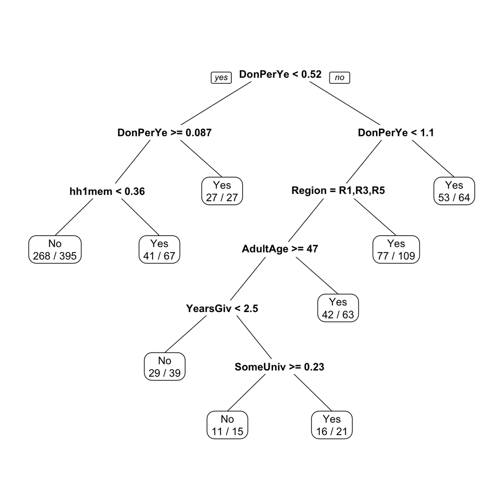

```r
> rpart.plot(noAorLDA012, type = 0, extra = 2, uniform = TRUE, fallen.leaves =
+   FALSE)
```

# Third model with adjusted complexity parameter(.013)

```r
> noAorLDA013 <- rpart(MonthGive ~ AdultAge + Age20t29 + Age20t39 + Age60pls +
+   Age80pls + Age70pls + AveIncEA + DonPerYear + DwelValEA + EngPrmLang + FinUnivP +
+   hh1mem + hh1t2mem + NewDonor + Region + SomeUnivP + YearsGive, data=CCS, cp=0.013,
+    subset=Sample == "Estimation")
```

## Plot

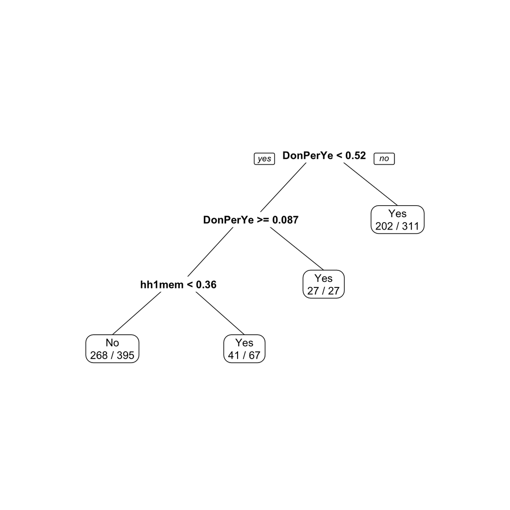

```r
> rpart.plot(noAorLDA013, type = 0, extra = 2, uniform = TRUE, fallen.leaves =
+   FALSE)
```

# Lift chart to assess models

```
[1] 0.49625
```

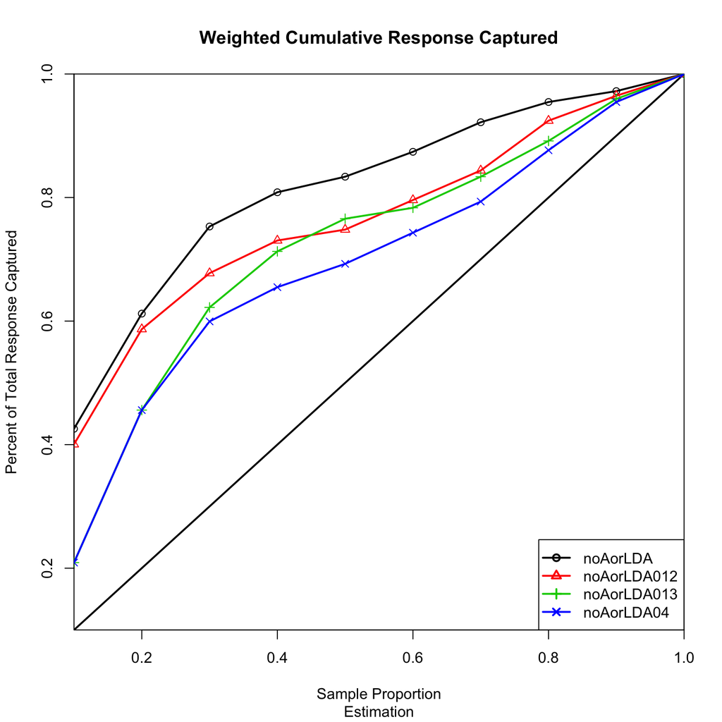

```r
> lift.chart(c("noAorLDA", "noAorLDA012", "noAorLDA013", "noAorLDA04"),
+   CCS[CCS$Sample == "Estimation",], "Yes", .01, "cumulative", "Estimation")
```

# Full Model(cp=.001)

```r
> Full001 <- rpart(MonthGive ~ AdultAge + Age20t29 + Age20t39 + Age60pls + Age80pls
+   + Age70pls + AveIncEA + DonPerYear + DwelValEA + EngPrmLang + FinUnivP + hh1mem +
+   hh1t2mem + NewDonor + Region + SomeUnivP + YearsGive + AveDonAmt + LastDonAmt,
+   data=CCS, cp=0.001, subset=Sample == "Estimation")
> printcp(Full001) # Pruning Table
```

```
Classification tree:
rpart(formula = MonthGive ~ AdultAge + Age20t29 + Age20t39 +
    Age60pls + Age80pls + Age70pls + AveIncEA + DonPerYear +
    DwelValEA + EngPrmLang + FinUnivP + hh1mem + hh1t2mem + NewDonor +
    Region + SomeUnivP + YearsGive + AveDonAmt + LastDonAmt,
    data = CCS, subset = Sample == "Estimation", cp = 0.001)

Variables actually used in tree construction:
 [1] AdultAge   Age20t29   Age20t39   Age60pls   Age80pls   AveDonAmt
 [7] AveIncEA   DonPerYear DwelValEA  FinUnivP   hh1t2mem   LastDonAmt
[13] Region     SomeUnivP  YearsGive

Root node error: 397/800 = 0.49625

n= 800

          CP nsplit rel error  xerror     xstd
1  0.3853904      0   1.00000 1.07557 0.035541
2  0.0352645      1   0.61461 0.61965 0.032877
3  0.0125945      3   0.54408 0.57683 0.032203
4  0.0109152      4   0.53149 0.60202 0.032610
5  0.0067170      7   0.49874 0.61713 0.032839
6  0.0062972     12   0.46348 0.64736 0.033268
7  0.0050378     23   0.36272 0.64987 0.033302
8  0.0041982     25   0.35264 0.67758 0.033658
9  0.0025189     28   0.34005 0.69521 0.033868
10 0.0010000     31   0.33249 0.70277 0.033954
```

# Full Model 2(cp=.02)

```r
> Full02 <- rpart(MonthGive ~ AdultAge + Age20t29 + Age20t39 + Age60pls +
+   Age80pls + Age70pls + AveIncEA + DonPerYear + DwelValEA + EngPrmLang +
+   FinUnivP + hh1mem + hh1t2mem + NewDonor + Region + SomeUnivP + YearsGive +
+   AveDonAmt + LastDonAmt, data=CCS, cp=0.02, subset=Sample == "Estimation")
> printcp(Full02) # Pruning Table
```

```
Classification tree:
rpart(formula = MonthGive ~ AdultAge + Age20t29 + Age20t39 +
    Age60pls + Age80pls + Age70pls + AveIncEA + DonPerYear +
    DwelValEA + EngPrmLang + FinUnivP + hh1mem + hh1t2mem + NewDonor +
    Region + SomeUnivP + YearsGive + AveDonAmt + LastDonAmt,
    data = CCS, subset = Sample == "Estimation", cp = 0.02)

Variables actually used in tree construction:
[1] AveDonAmt AveIncEA

Root node error: 397/800 = 0.49625

n= 800

        CP nsplit rel error  xerror     xstd
1 0.385390      0   1.00000 1.07557 0.035541
2 0.035264      1   0.61461 0.61965 0.032877
3 0.020000      3   0.54408 0.56927 0.032076
```

## Plot

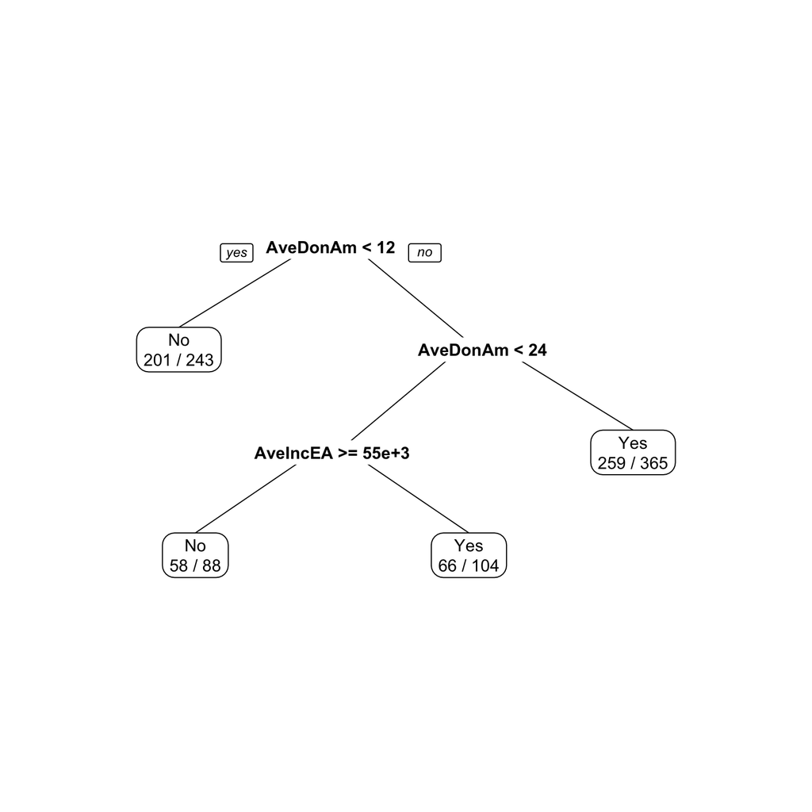

```r
> rpart.plot(Full02, type = 0, extra = 2, uniform = TRUE, fallen.leaves =
+   FALSE)
```

# Model with adjusted cp(.011)

```r
> Full011 <- rpart(MonthGive ~ AdultAge + Age20t29 + Age20t39 + Age60pls +
+   Age80pls + Age70pls + AveIncEA + DonPerYear + DwelValEA + EngPrmLang +
+   FinUnivP + hh1mem + hh1t2mem + NewDonor + Region + SomeUnivP + YearsGive +
+   AveDonAmt + LastDonAmt, data=CCS, cp=0.011, subset=Sample == "Estimation")
```

## Plot

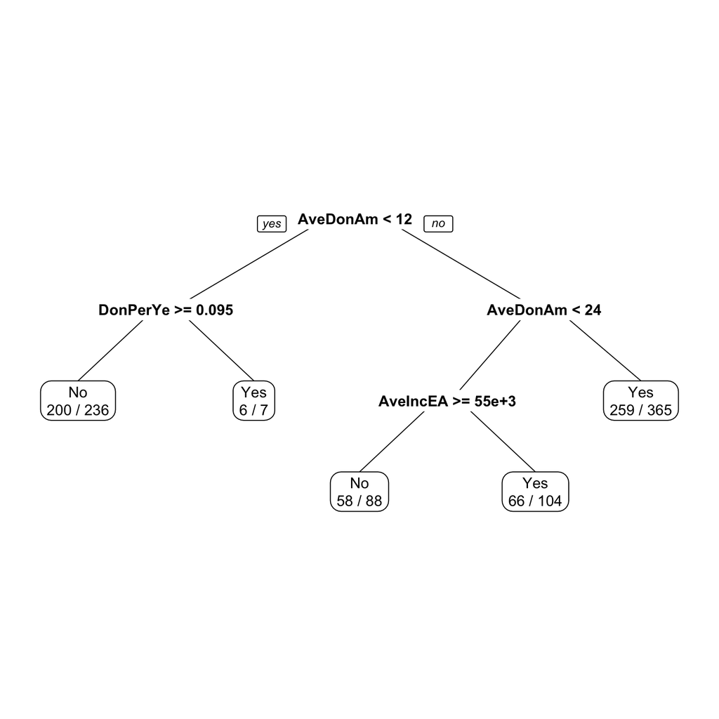

```r
> rpart.plot(Full011, type = 0, extra = 2, uniform = TRUE, fallen.leaves =
+   FALSE)
```

# Comparison of models using cumulative response liftchart

```
[1] 0.50375
```

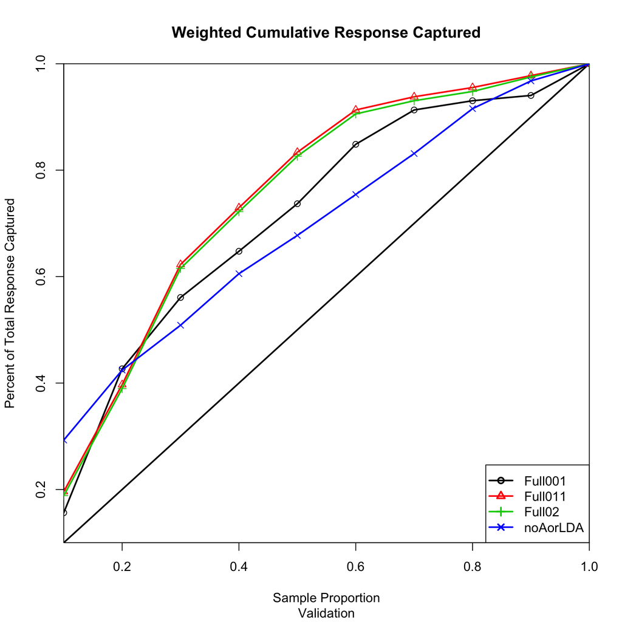

```r
> lift.chart(c("Full001", "Full011", "Full02", "noAorLDA"), CCS[CCS$Sample ==
+   "Validation",], "Yes", .01, "cumulative", "Validation")
```

Full011 appears to be the best performing model in this case.